# CASE

Dette caset ber oss vurdere datasettet *bank-full.csv*, som gir oss oversikt over data hentet fra markedsføringskampanjer utført mellom mai 2008 og november 2010 av en portugisisk bankinstitusjon. Vi ønsker spesfikt å se om vi kan klare å uttale oss om sammenheng mellom variablene i datasettet, og salg av et av bankens produkter

## Oppgave 1

Undersøk konklusjonene forfatterne kommer med i artikkelen omkring lengde av samtalen (variabelen `duration`), og hvilken måned samtalen er gjennomført i (variabelen `month`). Anta at det ikke er noen årseffekt for månedsvariabelen.

- Syntes du konklusjonene er fornuftige? Hvorfor / hvorfor ikke?

Det at det ikke er noen *årseffekt* her betyr at vi ikke har noe interaksjonseffekter som er spesifikke for året undersøkelsen ble gjennomført.

Spesifikt, vi har en variabel for hver av månedene undersøkelsen har blitt gjennomført i, men ingen variable for år.

Konklusjonen til forfatterne er:

*"Call duration is the most relevant feature, meaning that longer calls tend to increase successes. In second place comes the month of contact. Further analysis can show that success is most likely to occur in the last month of each trimester (March, June, September and December)".*

For å kunne foreta en vurdering av denne påstanden er vi nødt til å gjennomføre en logistisk regresjon. Dette krever imidlertid at vi først rydder opp i datasettet og klargjør det for analyse. Vi starter med å laste inn nødvendige moduler.

```python
import numpy as np
import pandas as pd
import matplotlib.pyplot as plt
import warnings
warnings.filterwarnings('ignore')
```

Vi kan dermed laste inn datasettet i en *pandas*-dataframe.

```python
df = pd.read_csv('bank-full.csv', sep = ';', header=0)
```

Vi kan sjekke at datasettet er blitt lastet inn som ønsket

```python
df
```

|  | age | job | marital | education | default | balance | housing | loan | contact | day | month | duration | campaign | pdays | previous | poutcome | y |
| --- | --- | --- | --- | --- | --- | --- | --- | --- | --- | --- | --- | --- | --- | --- | --- | --- | --- |
| 0 | 58 | management | married | tertiary | no | 2143 | yes | no | unknown | 5 | may | 261 | 1 | -1 | 0 | unknown | no |
| 1 | 44 | technician | single | secondary | no | 29 | yes | no | unknown | 5 | may | 151 | 1 | -1 | 0 | unknown | no |
| 2 | 33 | entrepreneur | married | secondary | no | 2 | yes | yes | unknown | 5 | may | 76 | 1 | -1 | 0 | unknown | no |
| 3 | 47 | blue-collar | married | unknown | no | 1506 | yes | no | unknown | 5 | may | 92 | 1 | -1 | 0 | unknown | no |
| 4 | 33 | unknown | single | unknown | no | 1 | no | no | unknown | 5 | may | 198 | 1 | -1 | 0 | unknown | no |
| 5 | 35 | management | married | tertiary | no | 231 | yes | no | unknown | 5 | may | 139 | 1 | -1 | 0 | unknown | no |
| 6 | 28 | management | single | tertiary | no | 447 | yes | yes | unknown | 5 | may | 217 | 1 | -1 | 0 | unknown | no |
| 7 | 42 | entrepreneur | divorced | tertiary | yes | 2 | yes | no | unknown | 5 | may | 380 | 1 | -1 | 0 | unknown | no |
| 8 | 58 | retired | married | primary | no | 121 | yes | no | unknown | 5 | may | 50 | 1 | -1 | 0 | unknown | no |
| 9 | 43 | technician | single | secondary | no | 593 | yes | no | unknown | 5 | may | 55 | 1 | -1 | 0 | unknown | no |
| 10 | 41 | admin. | divorced | secondary | no | 270 | yes | no | unknown | 5 | may | 222 | 1 | -1 | 0 | unknown | no |
| 11 | 29 | admin. | single | secondary | no | 390 | yes | no | unknown | 5 | may | 137 | 1 | -1 | 0 | unknown | no |
| 12 | 53 | technician | married | secondary | no | 6 | yes | no | unknown | 5 | may | 517 | 1 | -1 | 0 | unknown | no |
| 13 | 58 | technician | married | unknown | no | 71 | yes | no | unknown | 5 | may | 71 | 1 | -1 | 0 | unknown | no |
| 14 | 57 | services | married | secondary | no | 162 | yes | no | unknown | 5 | may | 174 | 1 | -1 | 0 | unknown | no |
| 15 | 51 | retired | married | primary | no | 229 | yes | no | unknown | 5 | may | 353 | 1 | -1 | 0 | unknown | no |
| 16 | 45 | admin. | single | unknown | no | 13 | yes | no | unknown | 5 | may | 98 | 1 | -1 | 0 | unknown | no |
| 17 | 57 | blue-collar | married | primary | no | 52 | yes | no | unknown | 5 | may | 38 | 1 | -1 | 0 | unknown | no |
| 18 | 60 | retired | married | primary | no | 60 | yes | no | unknown | 5 | may | 219 | 1 | -1 | 0 | unknown | no |
| 19 | 33 | services | married | secondary | no | 0 | yes | no | unknown | 5 | may | 54 | 1 | -1 | 0 | unknown | no |
| 20 | 28 | blue-collar | married | secondary | no | 723 | yes | yes | unknown | 5 | may | 262 | 1 | -1 | 0 | unknown | no |
| 21 | 56 | management | married | tertiary | no | 779 | yes | no | unknown | 5 | may | 164 | 1 | -1 | 0 | unknown | no |
| 22 | 32 | blue-collar | single | primary | no | 23 | yes | yes | unknown | 5 | may | 160 | 1 | -1 | 0 | unknown | no |
| 23 | 25 | services | married | secondary | no | 50 | yes | no | unknown | 5 | may | 342 | 1 | -1 | 0 | unknown | no |
| 24 | 40 | retired | married | primary | no | 0 | yes | yes | unknown | 5 | may | 181 | 1 | -1 | 0 | unknown | no |
| 25 | 44 | admin. | married | secondary | no | -372 | yes | no | unknown | 5 | may | 172 | 1 | -1 | 0 | unknown | no |
| 26 | 39 | management | single | tertiary | no | 255 | yes | no | unknown | 5 | may | 296 | 1 | -1 | 0 | unknown | no |
| 27 | 52 | entrepreneur | married | secondary | no | 113 | yes | yes | unknown | 5 | may | 127 | 1 | -1 | 0 | unknown | no |
| 28 | 46 | management | single | secondary | no | -246 | yes | no | unknown | 5 | may | 255 | 2 | -1 | 0 | unknown | no |
| 29 | 36 | technician | single | secondary | no | 265 | yes | yes | unknown | 5 | may | 348 | 1 | -1 | 0 | unknown | no |
| ... | ... | ... | ... | ... | ... | ... | ... | ... | ... | ... | ... | ... | ... | ... | ... | ... | ... |
| 45181 | 46 | blue-collar | married | secondary | no | 6879 | no | no | cellular | 15 | nov | 74 | 2 | 118 | 3 | failure | no |
| 45182 | 34 | technician | married | secondary | no | 133 | no | no | cellular | 15 | nov | 401 | 2 | 187 | 5 | success | yes |
| 45183 | 70 | retired | married | primary | no | 324 | no | no | cellular | 15 | nov | 78 | 1 | 96 | 7 | success | no |
| 45184 | 63 | retired | married | secondary | no | 1495 | no | no | cellular | 16 | nov | 138 | 1 | 22 | 5 | success | no |
| 45185 | 60 | services | married | tertiary | no | 4256 | yes | no | cellular | 16 | nov | 200 | 1 | 92 | 4 | success | yes |
| 45186 | 59 | unknown | married | unknown | no | 1500 | no | no | cellular | 16 | nov | 280 | 1 | 104 | 2 | failure | no |
| 45187 | 32 | services | single | secondary | no | 1168 | yes | no | cellular | 16 | nov | 411 | 1 | -1 | 0 | unknown | yes |
| 45188 | 29 | management | single | secondary | no | 703 | yes | no | cellular | 16 | nov | 236 | 1 | 550 | 2 | success | yes |
| 45189 | 25 | services | single | secondary | no | 199 | no | no | cellular | 16 | nov | 173 | 1 | 92 | 5 | failure | no |
| 45190 | 32 | blue-collar | married | secondary | no | 136 | no | no | cellular | 16 | nov | 206 | 1 | 188 | 3 | success | yes |
| 45191 | 75 | retired | divorced | tertiary | no | 3810 | yes | no | cellular | 16 | nov | 262 | 1 | 183 | 1 | failure | yes |
| 45192 | 29 | management | single | tertiary | no | 765 | no | no | cellular | 16 | nov | 238 | 1 | -1 | 0 | unknown | yes |
| 45193 | 28 | self-employed | single | tertiary | no | 159 | no | no | cellular | 16 | nov | 449 | 2 | 33 | 4 | success | yes |
| 45194 | 59 | management | married | tertiary | no | 138 | yes | yes | cellular | 16 | nov | 162 | 2 | 187 | 5 | failure | no |
| 45195 | 68 | retired | married | secondary | no | 1146 | no | no | cellular | 16 | nov | 212 | 1 | 187 | 6 | success | yes |
| 45196 | 25 | student | single | secondary | no | 358 | no | no | cellular | 16 | nov | 330 | 1 | -1 | 0 | unknown | yes |
| 45197 | 36 | management | single | secondary | no | 1511 | yes | no | cellular | 16 | nov | 270 | 1 | -1 | 0 | unknown | yes |
| 45198 | 37 | management | married | tertiary | no | 1428 | no | no | cellular | 16 | nov | 333 | 2 | -1 | 0 | unknown | no |
| 45199 | 34 | blue-collar | single | secondary | no | 1475 | yes | no | cellular | 16 | nov | 1166 | 3 | 530 | 12 | other | no |
| 45200 | 38 | technician | married | secondary | no | 557 | yes | no | cellular | 16 | nov | 1556 | 4 | -1 | 0 | unknown | yes |
| 45201 | 53 | management | married | tertiary | no | 583 | no | no | cellular | 17 | nov | 226 | 1 | 184 | 4 | success | yes |
| 45202 | 34 | admin. | single | secondary | no | 557 | no | no | cellular | 17 | nov | 224 | 1 | -1 | 0 | unknown | yes |
| 45203 | 23 | student | single | tertiary | no | 113 | no | no | cellular | 17 | nov | 266 | 1 | -1 | 0 | unknown | yes |
| 45204 | 73 | retired | married | secondary | no | 2850 | no | no | cellular | 17 | nov | 300 | 1 | 40 | 8 | failure | yes |
| 45205 | 25 | technician | single | secondary | no | 505 | no | yes | cellular | 17 | nov | 386 | 2 | -1 | 0 | unknown | yes |
| 45206 | 51 | technician | married | tertiary | no | 825 | no | no | cellular | 17 | nov | 977 | 3 | -1 | 0 | unknown | yes |
| 45207 | 71 | retired | divorced | primary | no | 1729 | no | no | cellular | 17 | nov | 456 | 2 | -1 | 0 | unknown | yes |
| 45208 | 72 | retired | married | secondary | no | 5715 | no | no | cellular | 17 | nov | 1127 | 5 | 184 | 3 | success | yes |
| 45209 | 57 | blue-collar | married | secondary | no | 668 | no | no | telephone | 17 | nov | 508 | 4 | -1 | 0 | unknown | no |
| 45210 | 37 | entrepreneur | married | secondary | no | 2971 | no | no | cellular | 17 | nov | 361 | 2 | 188 | 11 | other | no |

45211 rows × 17 columns

Dette er veldig mye informasjon på en gang, så det kan være greit å ta en titt på oppsummeringen

```python
df.info()
```

```
<class 'pandas.core.frame.DataFrame'>
RangeIndex: 45211 entries, 0 to 45210
Data columns (total 17 columns):
age          45211 non-null int64
job          45211 non-null object
marital      45211 non-null object
education    45211 non-null object
default      45211 non-null object
balance      45211 non-null int64
housing      45211 non-null object
loan         45211 non-null object
contact      45211 non-null object
day          45211 non-null int64
month        45211 non-null object
duration     45211 non-null int64
campaign     45211 non-null int64
pdays        45211 non-null int64
previous     45211 non-null int64
poutcome     45211 non-null object
y            45211 non-null object
dtypes: int64(7), object(10)
memory usage: 5.9+ MB
```

Og vi kan dermed også bedrive enkel deskriptiv statistikk

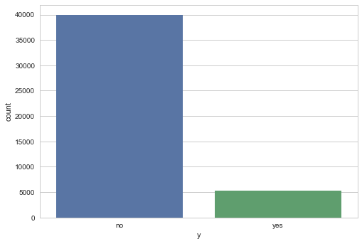

```python
import seaborn as sns
sns.set(style="white")
sns.set(style="whitegrid", color_codes=True)
sns.countplot(x='y', data=df)
plt.show()
```

```python
df.groupby('y').mean()
```

| y | age | balance | day | duration | campaign | pdays | previous |
| --- | --- | --- | --- | --- | --- | --- | --- |
| no | 40.838986 | 1303.714969 | 15.892290 | 221.182806 | 2.846350 | 36.421372 | 0.502154 |
| yes | 41.670070 | 1804.267915 | 15.158253 | 537.294574 | 2.141047 | 68.702968 | 1.170354 |

Vi kan se at det er noen problematiske variable i forbindelse med en eventuell regresjonsmodell. Eksempelvis:

```python
df['month']
```

```
0        may
1        may
2        may
3        may
4        may
5        may
6        may
7        may
8        may
9        may
10       may
11       may
12       may
13       may
14       may
```

[output cut: 47 more lines]

Vi er dermed nødt til å gjøre om på de kategoriske variablene.

```python
categories = ['job', 'marital', 'education', 'contact', 'month', 'poutcome']
for var in categories:
    cat_list='var'+'_'+var
    cat_list = pd.get_dummies(df[var], drop_first=True, prefix=var)
    df = df.join(cat_list)

df
```

|  | age | job | marital | education | default | balance | housing | loan | contact | day | ... | month_jul | month_jun | month_mar | month_may | month_nov | month_oct | month_sep | poutcome_other | poutcome_success | poutcome_unknown |
| --- | --- | --- | --- | --- | --- | --- | --- | --- | --- | --- | --- | --- | --- | --- | --- | --- | --- | --- | --- | --- | --- |
| 0 | 58 | management | married | tertiary | no | 2143 | yes | no | unknown | 5 | ... | 0 | 0 | 0 | 1 | 0 | 0 | 0 | 0 | 0 | 1 |
| 1 | 44 | technician | single | secondary | no | 29 | yes | no | unknown | 5 | ... | 0 | 0 | 0 | 1 | 0 | 0 | 0 | 0 | 0 | 1 |
| 2 | 33 | entrepreneur | married | secondary | no | 2 | yes | yes | unknown | 5 | ... | 0 | 0 | 0 | 1 | 0 | 0 | 0 | 0 | 0 | 1 |
| 3 | 47 | blue-collar | married | unknown | no | 1506 | yes | no | unknown | 5 | ... | 0 | 0 | 0 | 1 | 0 | 0 | 0 | 0 | 0 | 1 |
| 4 | 33 | unknown | single | unknown | no | 1 | no | no | unknown | 5 | ... | 0 | 0 | 0 | 1 | 0 | 0 | 0 | 0 | 0 | 1 |
| 5 | 35 | management | married | tertiary | no | 231 | yes | no | unknown | 5 | ... | 0 | 0 | 0 | 1 | 0 | 0 | 0 | 0 | 0 | 1 |
| 6 | 28 | management | single | tertiary | no | 447 | yes | yes | unknown | 5 | ... | 0 | 0 | 0 | 1 | 0 | 0 | 0 | 0 | 0 | 1 |
| 7 | 42 | entrepreneur | divorced | tertiary | yes | 2 | yes | no | unknown | 5 | ... | 0 | 0 | 0 | 1 | 0 | 0 | 0 | 0 | 0 | 1 |
| 8 | 58 | retired | married | primary | no | 121 | yes | no | unknown | 5 | ... | 0 | 0 | 0 | 1 | 0 | 0 | 0 | 0 | 0 | 1 |
| 9 | 43 | technician | single | secondary | no | 593 | yes | no | unknown | 5 | ... | 0 | 0 | 0 | 1 | 0 | 0 | 0 | 0 | 0 | 1 |
| 10 | 41 | admin. | divorced | secondary | no | 270 | yes | no | unknown | 5 | ... | 0 | 0 | 0 | 1 | 0 | 0 | 0 | 0 | 0 | 1 |
| 11 | 29 | admin. | single | secondary | no | 390 | yes | no | unknown | 5 | ... | 0 | 0 | 0 | 1 | 0 | 0 | 0 | 0 | 0 | 1 |
| 12 | 53 | technician | married | secondary | no | 6 | yes | no | unknown | 5 | ... | 0 | 0 | 0 | 1 | 0 | 0 | 0 | 0 | 0 | 1 |
| 13 | 58 | technician | married | unknown | no | 71 | yes | no | unknown | 5 | ... | 0 | 0 | 0 | 1 | 0 | 0 | 0 | 0 | 0 | 1 |
| 14 | 57 | services | married | secondary | no | 162 | yes | no | unknown | 5 | ... | 0 | 0 | 0 | 1 | 0 | 0 | 0 | 0 | 0 | 1 |
| 15 | 51 | retired | married | primary | no | 229 | yes | no | unknown | 5 | ... | 0 | 0 | 0 | 1 | 0 | 0 | 0 | 0 | 0 | 1 |
| 16 | 45 | admin. | single | unknown | no | 13 | yes | no | unknown | 5 | ... | 0 | 0 | 0 | 1 | 0 | 0 | 0 | 0 | 0 | 1 |
| 17 | 57 | blue-collar | married | primary | no | 52 | yes | no | unknown | 5 | ... | 0 | 0 | 0 | 1 | 0 | 0 | 0 | 0 | 0 | 1 |
| 18 | 60 | retired | married | primary | no | 60 | yes | no | unknown | 5 | ... | 0 | 0 | 0 | 1 | 0 | 0 | 0 | 0 | 0 | 1 |
| 19 | 33 | services | married | secondary | no | 0 | yes | no | unknown | 5 | ... | 0 | 0 | 0 | 1 | 0 | 0 | 0 | 0 | 0 | 1 |
| 20 | 28 | blue-collar | married | secondary | no | 723 | yes | yes | unknown | 5 | ... | 0 | 0 | 0 | 1 | 0 | 0 | 0 | 0 | 0 | 1 |
| 21 | 56 | management | married | tertiary | no | 779 | yes | no | unknown | 5 | ... | 0 | 0 | 0 | 1 | 0 | 0 | 0 | 0 | 0 | 1 |
| 22 | 32 | blue-collar | single | primary | no | 23 | yes | yes | unknown | 5 | ... | 0 | 0 | 0 | 1 | 0 | 0 | 0 | 0 | 0 | 1 |
| 23 | 25 | services | married | secondary | no | 50 | yes | no | unknown | 5 | ... | 0 | 0 | 0 | 1 | 0 | 0 | 0 | 0 | 0 | 1 |
| 24 | 40 | retired | married | primary | no | 0 | yes | yes | unknown | 5 | ... | 0 | 0 | 0 | 1 | 0 | 0 | 0 | 0 | 0 | 1 |
| 25 | 44 | admin. | married | secondary | no | -372 | yes | no | unknown | 5 | ... | 0 | 0 | 0 | 1 | 0 | 0 | 0 | 0 | 0 | 1 |
| 26 | 39 | management | single | tertiary | no | 255 | yes | no | unknown | 5 | ... | 0 | 0 | 0 | 1 | 0 | 0 | 0 | 0 | 0 | 1 |
| 27 | 52 | entrepreneur | married | secondary | no | 113 | yes | yes | unknown | 5 | ... | 0 | 0 | 0 | 1 | 0 | 0 | 0 | 0 | 0 | 1 |
| 28 | 46 | management | single | secondary | no | -246 | yes | no | unknown | 5 | ... | 0 | 0 | 0 | 1 | 0 | 0 | 0 | 0 | 0 | 1 |
| 29 | 36 | technician | single | secondary | no | 265 | yes | yes | unknown | 5 | ... | 0 | 0 | 0 | 1 | 0 | 0 | 0 | 0 | 0 | 1 |
| ... | ... | ... | ... | ... | ... | ... | ... | ... | ... | ... | ... | ... | ... | ... | ... | ... | ... | ... | ... | ... | ... |
| 45181 | 46 | blue-collar | married | secondary | no | 6879 | no | no | cellular | 15 | ... | 0 | 0 | 0 | 0 | 1 | 0 | 0 | 0 | 0 | 0 |
| 45182 | 34 | technician | married | secondary | no | 133 | no | no | cellular | 15 | ... | 0 | 0 | 0 | 0 | 1 | 0 | 0 | 0 | 1 | 0 |
| 45183 | 70 | retired | married | primary | no | 324 | no | no | cellular | 15 | ... | 0 | 0 | 0 | 0 | 1 | 0 | 0 | 0 | 1 | 0 |
| 45184 | 63 | retired | married | secondary | no | 1495 | no | no | cellular | 16 | ... | 0 | 0 | 0 | 0 | 1 | 0 | 0 | 0 | 1 | 0 |
| 45185 | 60 | services | married | tertiary | no | 4256 | yes | no | cellular | 16 | ... | 0 | 0 | 0 | 0 | 1 | 0 | 0 | 0 | 1 | 0 |
| 45186 | 59 | unknown | married | unknown | no | 1500 | no | no | cellular | 16 | ... | 0 | 0 | 0 | 0 | 1 | 0 | 0 | 0 | 0 | 0 |
| 45187 | 32 | services | single | secondary | no | 1168 | yes | no | cellular | 16 | ... | 0 | 0 | 0 | 0 | 1 | 0 | 0 | 0 | 0 | 1 |
| 45188 | 29 | management | single | secondary | no | 703 | yes | no | cellular | 16 | ... | 0 | 0 | 0 | 0 | 1 | 0 | 0 | 0 | 1 | 0 |
| 45189 | 25 | services | single | secondary | no | 199 | no | no | cellular | 16 | ... | 0 | 0 | 0 | 0 | 1 | 0 | 0 | 0 | 0 | 0 |
| 45190 | 32 | blue-collar | married | secondary | no | 136 | no | no | cellular | 16 | ... | 0 | 0 | 0 | 0 | 1 | 0 | 0 | 0 | 1 | 0 |
| 45191 | 75 | retired | divorced | tertiary | no | 3810 | yes | no | cellular | 16 | ... | 0 | 0 | 0 | 0 | 1 | 0 | 0 | 0 | 0 | 0 |
| 45192 | 29 | management | single | tertiary | no | 765 | no | no | cellular | 16 | ... | 0 | 0 | 0 | 0 | 1 | 0 | 0 | 0 | 0 | 1 |
| 45193 | 28 | self-employed | single | tertiary | no | 159 | no | no | cellular | 16 | ... | 0 | 0 | 0 | 0 | 1 | 0 | 0 | 0 | 1 | 0 |
| 45194 | 59 | management | married | tertiary | no | 138 | yes | yes | cellular | 16 | ... | 0 | 0 | 0 | 0 | 1 | 0 | 0 | 0 | 0 | 0 |
| 45195 | 68 | retired | married | secondary | no | 1146 | no | no | cellular | 16 | ... | 0 | 0 | 0 | 0 | 1 | 0 | 0 | 0 | 1 | 0 |
| 45196 | 25 | student | single | secondary | no | 358 | no | no | cellular | 16 | ... | 0 | 0 | 0 | 0 | 1 | 0 | 0 | 0 | 0 | 1 |
| 45197 | 36 | management | single | secondary | no | 1511 | yes | no | cellular | 16 | ... | 0 | 0 | 0 | 0 | 1 | 0 | 0 | 0 | 0 | 1 |
| 45198 | 37 | management | married | tertiary | no | 1428 | no | no | cellular | 16 | ... | 0 | 0 | 0 | 0 | 1 | 0 | 0 | 0 | 0 | 1 |
| 45199 | 34 | blue-collar | single | secondary | no | 1475 | yes | no | cellular | 16 | ... | 0 | 0 | 0 | 0 | 1 | 0 | 0 | 1 | 0 | 0 |
| 45200 | 38 | technician | married | secondary | no | 557 | yes | no | cellular | 16 | ... | 0 | 0 | 0 | 0 | 1 | 0 | 0 | 0 | 0 | 1 |
| 45201 | 53 | management | married | tertiary | no | 583 | no | no | cellular | 17 | ... | 0 | 0 | 0 | 0 | 1 | 0 | 0 | 0 | 1 | 0 |
| 45202 | 34 | admin. | single | secondary | no | 557 | no | no | cellular | 17 | ... | 0 | 0 | 0 | 0 | 1 | 0 | 0 | 0 | 0 | 1 |
| 45203 | 23 | student | single | tertiary | no | 113 | no | no | cellular | 17 | ... | 0 | 0 | 0 | 0 | 1 | 0 | 0 | 0 | 0 | 1 |
| 45204 | 73 | retired | married | secondary | no | 2850 | no | no | cellular | 17 | ... | 0 | 0 | 0 | 0 | 1 | 0 | 0 | 0 | 0 | 0 |
| 45205 | 25 | technician | single | secondary | no | 505 | no | yes | cellular | 17 | ... | 0 | 0 | 0 | 0 | 1 | 0 | 0 | 0 | 0 | 1 |
| 45206 | 51 | technician | married | tertiary | no | 825 | no | no | cellular | 17 | ... | 0 | 0 | 0 | 0 | 1 | 0 | 0 | 0 | 0 | 1 |
| 45207 | 71 | retired | divorced | primary | no | 1729 | no | no | cellular | 17 | ... | 0 | 0 | 0 | 0 | 1 | 0 | 0 | 0 | 0 | 1 |
| 45208 | 72 | retired | married | secondary | no | 5715 | no | no | cellular | 17 | ... | 0 | 0 | 0 | 0 | 1 | 0 | 0 | 0 | 1 | 0 |
| 45209 | 57 | blue-collar | married | secondary | no | 668 | no | no | telephone | 17 | ... | 0 | 0 | 0 | 0 | 1 | 0 | 0 | 0 | 0 | 1 |
| 45210 | 37 | entrepreneur | married | secondary | no | 2971 | no | no | cellular | 17 | ... | 0 | 0 | 0 | 0 | 1 | 0 | 0 | 1 | 0 | 0 |

45211 rows × 49 columns

Kan være greit å rydde opp tilsvarende i boolske variable:

```python
bools = ['default', 'housing', 'loan', 'y']

def boolean(df, name):
    df[name] = (df[name] == 'yes').astype(int)
    return df

for var in bools:
    df = boolean(df, var)
```

Vi oppretter konstantledd, og fjerner unødvendige originale variable

```python
df['intercept'] = 1
variables = (df.columns.values.tolist())
keep = [i for i in variables if i not in categories]
data = df[keep]
```

Og tar en titt på det nye datasettet:

```python
data.info()
```

```
<class 'pandas.core.frame.DataFrame'>
RangeIndex: 45211 entries, 0 to 45210
Data columns (total 44 columns):
age                    45211 non-null int64
default                45211 non-null int32
balance                45211 non-null int64
housing                45211 non-null int32
loan                   45211 non-null int32
day                    45211 non-null int64
duration               45211 non-null int64
campaign               45211 non-null int64
pdays                  45211 non-null int64
previous               45211 non-null int64
y                      45211 non-null int32
job_blue-collar        45211 non-null uint8
job_entrepreneur       45211 non-null uint8
job_housemaid          45211 non-null uint8
job_management         45211 non-null uint8
job_retired            45211 non-null uint8
job_self-employed      45211 non-null uint8
job_services           45211 non-null uint8
job_student            45211 non-null uint8
job_technician         45211 non-null uint8
job_unemployed         45211 non-null uint8
job_unknown            45211 non-null uint8
marital_married        45211 non-null uint8
marital_single         45211 non-null uint8
education_secondary    45211 non-null uint8
education_tertiary     45211 non-null uint8
education_unknown      45211 non-null uint8
contact_telephone      45211 non-null uint8
contact_unknown        45211 non-null uint8
month_aug              45211 non-null uint8
month_dec              45211 non-null uint8
month_feb              45211 non-null uint8
month_jan              45211 non-null uint8
month_jul              45211 non-null uint8
month_jun              45211 non-null uint8
month_mar              45211 non-null uint8
month_may              45211 non-null uint8
month_nov              45211 non-null uint8
month_oct              45211 non-null uint8
month_sep              45211 non-null uint8
poutcome_other         45211 non-null uint8
poutcome_success       45211 non-null uint8
poutcome_unknown       45211 non-null uint8
intercept              45211 non-null int64
dtypes: int32(4), int64(8), uint8(32)
memory usage: 4.8 MB
```

```python
df.groupby("y").mean()
```

| y | age | default | balance | housing | loan | day | duration | campaign | pdays | previous | ... | month_jun | month_mar | month_may | month_nov | month_oct | month_sep | poutcome_other | poutcome_success | poutcome_unknown | intercept |
| --- | --- | --- | --- | --- | --- | --- | --- | --- | --- | --- | --- | --- | --- | --- | --- | --- | --- | --- | --- | --- | --- |
| 0 | 40.838986 | 0.019112 | 1303.714969 | 0.581008 | 0.169330 | 15.892290 | 221.182806 | 2.846350 | 36.421372 | 0.502154 | ... | 0.120109 | 0.005736 | 0.321652 | 0.089349 | 0.010395 | 0.007765 | 0.038400 | 0.013351 | 0.840965 | 1.0 |
| 1 | 41.670070 | 0.009832 | 1804.267915 | 0.365854 | 0.091511 | 15.158253 | 537.294574 | 2.141047 | 68.702968 | 1.170354 | ... | 0.103233 | 0.046890 | 0.174891 | 0.076196 | 0.061070 | 0.050860 | 0.058045 | 0.184912 | 0.640197 | 1.0 |

2 rows × 43 columns

```python
cumulative = 0
months = ['jan', 'feb', 'mar', 'may', 'jun', 'jul', 'aug', 'sep', 'oct', 'nov', 'dec']
for month in months:
    i = 'month_' + month
    cumulative += df.groupby('y')[i].mean()
print(cumulative)
```

```
y
0    0.941010
1    0.890906
Name: month_jan, dtype: float64
```

Vi kan nå sette opp en enkel regresjonsmodell:

```python
y = ['y']
x = [i for i in keep if i not in y]
Y = data[y]
X = data[x]

import statsmodels.api as sm

logit_model = sm.Logit(Y,X)
result = logit_model.fit()
print(result.summary2())
```

```
Optimization terminated successfully.
         Current function value: 0.238463
         Iterations 8
                           Results: Logit
====================================================================
Model:               Logit             No. Iterations:    8.0000
Dependent Variable:  y                 Pseudo R-squared:  0.339
Date:                2018-11-28 12:46  AIC:               21648.2702
No. Observations:    45211             BIC:               22023.1913
Df Model:            42                Log-Likelihood:    -10781.
Df Residuals:        45168             LL-Null:           -16315.
Converged:           1.0000            Scale:             1.0000
--------------------------------------------------------------------
                     Coef.  Std.Err.    z     P>|z|   [0.025  0.975]
--------------------------------------------------------------------
age                  0.0001   0.0022   0.0511 0.9592 -0.0042  0.0044
default             -0.0167   0.1628  -0.1024 0.9184 -0.3358  0.3025
balance              0.0000   0.0000   2.4934 0.0127  0.0000  0.0000
housing             -0.6754   0.0439 -15.3953 0.0000 -0.7614 -0.5894
loan                -0.4254   0.0600  -7.0906 0.0000 -0.5430 -0.3078
day                  0.0100   0.0025   3.9929 0.0001  0.0051  0.0149
duration             0.0042   0.0001  64.9852 0.0000  0.0041  0.0043
campaign            -0.0908   0.0101  -8.9551 0.0000 -0.1107 -0.0709
pdays               -0.0001   0.0003  -0.3355 0.7373 -0.0007  0.0005
previous             0.0102   0.0065   1.5612 0.1185 -0.0026  0.0229
job_blue-collar     -0.3099   0.0727  -4.2641 0.0000 -0.4523 -0.1674
job_entrepreneur    -0.3571   0.1256  -2.8440 0.0045 -0.6032 -0.1110
job_housemaid       -0.5040   0.1365  -3.6931 0.0002 -0.7715 -0.2365
job_management      -0.1653   0.0733  -2.2550 0.0241 -0.3089 -0.0216
job_retired          0.2524   0.0972   2.5958 0.0094  0.0618  0.4429
job_self-employed   -0.2983   0.1120  -2.6638 0.0077 -0.5178 -0.0788
job_services        -0.2238   0.0841  -2.6622 0.0078 -0.3886 -0.0590
job_student          0.3821   0.1090   3.5049 0.0005  0.1684  0.5958
job_technician      -0.1760   0.0689  -2.5535 0.0107 -0.3111 -0.0409
job_unemployed      -0.1767   0.1116  -1.5828 0.1135 -0.3955  0.0421
job_unknown         -0.3133   0.2335  -1.3418 0.1797 -0.7708  0.1443
marital_married     -0.1795   0.0589  -3.0462 0.0023 -0.2949 -0.0640
marital_single       0.0925   0.0673   1.3752 0.1691 -0.0393  0.2243
education_secondary  0.1835   0.0648   2.8325 0.0046  0.0565  0.3105
education_tertiary   0.3789   0.0753   5.0311 0.0000  0.2313  0.5266
education_unknown    0.2505   0.1039   2.4108 0.0159  0.0468  0.4541
contact_telephone   -0.1634   0.0752  -2.1729 0.0298 -0.3107 -0.0160
contact_unknown     -1.6232   0.0732 -22.1831 0.0000 -1.7666 -1.4798
month_aug           -0.6939   0.0785  -8.8424 0.0000 -0.8477 -0.5401
month_dec            0.6911   0.1767   3.9117 0.0001  0.3448  1.0374
month_feb           -0.1473   0.0894  -1.6476 0.0994 -0.3226  0.0279
month_jan           -1.2617   0.1217 -10.3672 0.0000 -1.5003 -1.0232
month_jul           -0.8308   0.0774 -10.7331 0.0000 -0.9825 -0.6791
month_jun            0.4536   0.0937   4.8428 0.0000  0.2700  0.6372
month_mar            1.5899   0.1199  13.2652 0.0000  1.3550  1.8248
month_may           -0.3991   0.0723  -5.5213 0.0000 -0.5408 -0.2574
month_nov           -0.8734   0.0844 -10.3471 0.0000 -1.0388 -0.7080
month_oct            0.8814   0.1080   8.1591 0.0000  0.6697  1.0932
month_sep            0.8741   0.1195   7.3144 0.0000  0.6398  1.1083
poutcome_other       0.2035   0.0899   2.2645 0.0235  0.0274  0.3796
poutcome_success     2.2911   0.0823  27.8212 0.0000  2.1297  2.4525
poutcome_unknown    -0.0918   0.0935  -0.9820 0.3261 -0.2750  0.0914
intercept           -2.5356   0.1837 -13.8028 0.0000 -2.8957 -2.1756
====================================================================
```

## Oppgave 2

Lag en ny variable som teller antall av oppkall per dag (en rad er ett oppkall), igjen antar vi ingen årseffekt.

- Plot denne nye variablene mot suksessraten for dagen
- Hva mener du dette plottet viser, dra gjerne i spørsmål 1.

Fant ingen intuitiv måte å gjøre dette i *pandas*. Problemet består av at vi ikke har kjennskap til hvilke kombinasjoner av måneder og dager som er gyldige. Vi må derfor fort løkke over datasettet, og lete etter tilfeller der vi møter nye kombinasjoner.

Løsningen ble dictionaries. Dette er neppe optimalt, men fungerer greit for anledningen.

```python
df = pd.read_csv('bank-full.csv', sep = ';', header=0)

data = df[['day', 'month', 'y']]
dict = {}

for i in range(len(data)):
    m = data.iloc[i].month
    if m not in dict.keys():
        dict[m] = {}
    d = data.iloc[i].day
    if d not in dict[m].keys():
        dict[m][d] = [0,0]
    s = data.iloc[i].y
    if s == 'yes':
        dict[m][d][1] += 1
    dict[m][d][0] += 1
```

Vi kan nå hente ut data om suksessrate per måned

```python
M = {}
for m in dict.keys():
    n = 0; s = 0;
    for d in dict[m].keys():
        n += dict[m][d][0]
        s += dict[m][d][1]
    M[m] = [s/n]

months = {'jan': 1, 'feb': 2, 'mar': 3, 'apr': 4, 'may': 5, 'jun': 6,\
          'jul': 7, 'aug': 8, 'sep': 9, 'oct': 10, 'nov': 11, 'dec': 12}

R = [[],[]]
i = 0
for keys in M:
    R[0].append((M[keys][0]))
    R[1].append(months[keys])
    i += 1
```

Plotter vi dette får vi

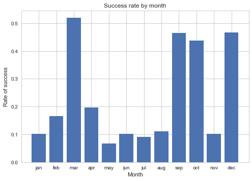

```python
R = np.asarray(R)
R.sort(axis=0)
plt.figure()
my_xticks = ['jan','feb','mar','apr','may','jun','jul','aug','sep','oct','nov','dec']
plt.xticks(range(1,13), my_xticks)
plt.bar(R[1,:], R[0,:])
plt.legend()
plt.xlabel('Month')
plt.ylabel('Rate of success')
plt.title('Success rate by month')
plt.show()
```

Vi kan også hente ut informasjon om verdiene hver av dagene.

```python
N = []
S = []
for m in dict.keys():
    for d in dict[m].keys():
        n = dict[m][d][0]
        s = dict[m][d][1]
        N.append(n)
        S.append(s)
```

Med dette gjort kan vi nå plotte verdiene mot hverandre

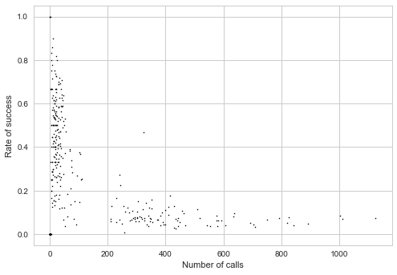

```python
X = np.array([N,S])
plt.scatter(X[0], X[1]/X[0], marker='x', s=.2, color='black')
plt.xlabel('Number of calls')
plt.ylabel('Rate of success')
plt.show()
```

Denne er morsom, fordi vi både får et intuitivt og kontraintuitivt resultat. Plottet viser at desto færre vi ringer, desto høyere suksessrate. Samtidig kan vi tenke til oppgave 1, hvor vi vet at en økt duration gir økt suksessrate. Dette vil jo følgelig også medføre færre oppringniger.

Det er viktig å huske at dette plottet *ikke* viser en fullstendig sammenheng!

1-1 punktet er 13. juni, og varte i 674 sekunder. Name: 43902